# Analyse von Zeitreihen mit ‘polmineR’

Beispielanalysen mit dem GermaParl-Korpus

Andreas Blaette

13 Mai 2018

# Initialisierung

Die Beispiele basieren auf dem GermaParl-Korpus. Der Datensatz in dem Paket muss nach dem Laden von polmineR mit dem `use-Befehl aktiviert werden.

```r
library(polmineR)
use("GermaParl")
```

Wenn Sie den Code der folgenden Beispiele auf Ihrem eigenen Rechner nachvollziehen möchten, können Sie das ‘Rmarkdown’-Dokument, mit dem der Foliensatz generiert wurde, direkt in R laden:

```r
if (!"RCurl" %in% rownames(installed.packages())) install.packages("RCurl")
library(RCurl)
script <- getURL(
  "https://raw.githubusercontent.com/PolMine/polmineR.tutorials/master/polmineR_Zeitreihen.Rmd",
  ssl.verifypeer = FALSE
  )
```

Speichern Sie das Skript auf Ihrem Schreibtisch - oder an einem anderen Speicherort.

```r
filename <- "~/Desktop/polmineR_tutorial_zeitreihen.Rmd"
if (interactive()) writeLines(text = script, con = filename)
```

Wenn Sie jetzt das Dokument öffnen, können Sie den Code Schritt für Schritt nachvollziehen (und auf Ihre Bedürfnisse anpassen).

# Zeit und Häufigkeitsverteilungen

Die Häufigkeit von Worten (im Sinne von Schlagworten) oder von Suchbegriffen lässt sich mit der `count`-Methode bestimmen. Die `dispersion`-Methode vollzieht die Zählung über ein oder zwei strukturelle Attribute (d.h. Dimensionen).

```r
dt <- dispersion("GERMAPARL", query = "Flüchtlinge", sAttribute = "year")
head(dt) # wir betrachten nur den Anfang der Tabelle
```

```
##    year count
## 1: 1996   217
## 2: 1997   129
## 3: 1998   151
## 4: 1999   368
## 5: 2000   161
## 6: 2001   127
```

Eine schöne und praktische Ansicht bietet die `View`-Funktion von RStudio.

```r
View(dt)
```

Der Rückgabewert die `dispersion`-Methode ist ein `data.table`. Wenn Sie es gewöhnt sind, mit `data.frame`-Objekten zu arbeiten, können Sie die Umwandlung leicht vollziehen.

```r
df <- as.data.frame(dt)
```

# Einfache Visualisierung der Häufigkeiten

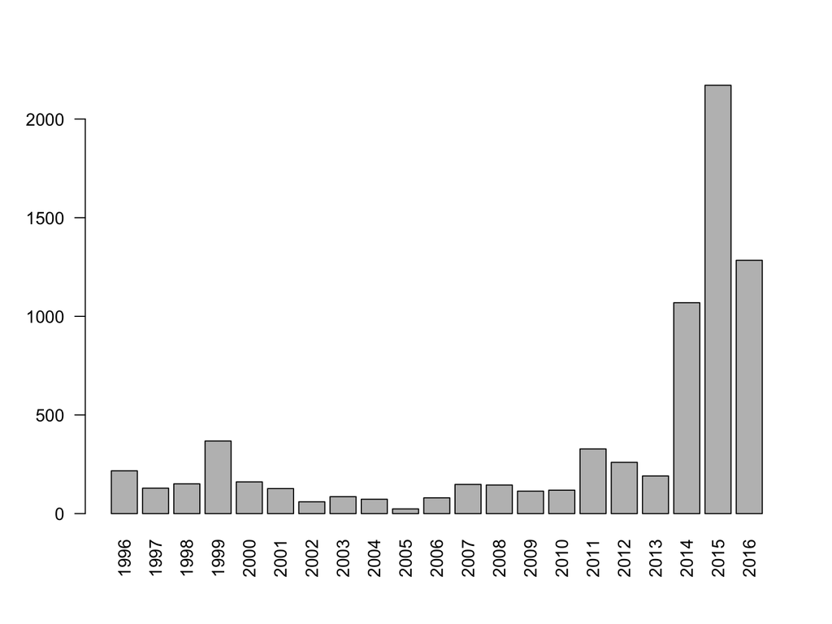

```r
barplot(height = df[["count"]], names.arg = df[["year"]], las = 2)
```

Dieses einfache Balkendiagramm bestätigt bereits die Vermutung, dass der sprunghafte Anstieg der Fluchtmigration von 2015 auch im Bundestag erheblichen Widerhall hatte.

# Häufigkeitsverteilung über zwei Dimensionen

Der Analyse fügen wir jetzt noch als zweite Dimension eine Differenzierung nach Parteien hinzu.

```r
dt <- dispersion("GERMAPARL", query = "Flüchtlinge", sAttribute = c("year", "party"))
```

Für die Arbeit mit Zeitreihen-Daten nutzen wir das `xts`-Paket, das bei Bedarf zuerst installiert wird.

```r
if (!"xts" %in% rownames(installed.packages())) install.packages("xts")
library(xts)
```

Wir erzeugen nun ein `xts`-Objekt auf Basis der schon erfolgten Kreuztabelle mit den Häufigkeiten und schauen, wie das aussieht.

```r
ts <- xts(x = dt[,c("CDU", "CSU", "FDP", "GRUENE", "SPD")],
          order.by = as.Date(sprintf("%s-01-01", dt[["year"]])))
head(ts)
```

```
##            CDU CSU FDP GRUENE SPD
## 1996-01-01  44  11  24     56  59
## 1997-01-01  30   8  16     34  22
## 1998-01-01  32   2  26     39  27
## 1999-01-01  92  11  14     40 164
## 2000-01-01  32   2  10     40  54
## 2001-01-01  11   3   6     36  51
```

# Visualisierung des Zeitverlaufs

Besser sind die Dinge über ein Zeitreihen-Diagramm zu erkennen.

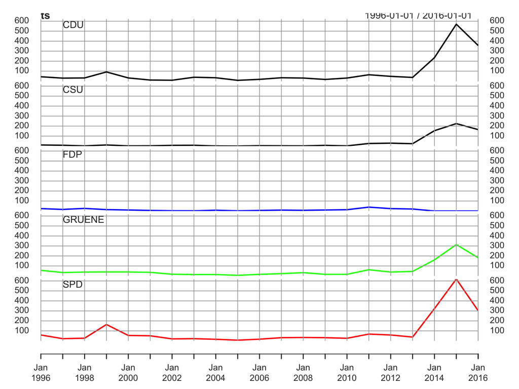

```r
plot(ts, multi.panel = TRUE, col = c("black", "black", "blue", "green", "red"), lwd = 2)
```

# Was passiert während der Jahre?

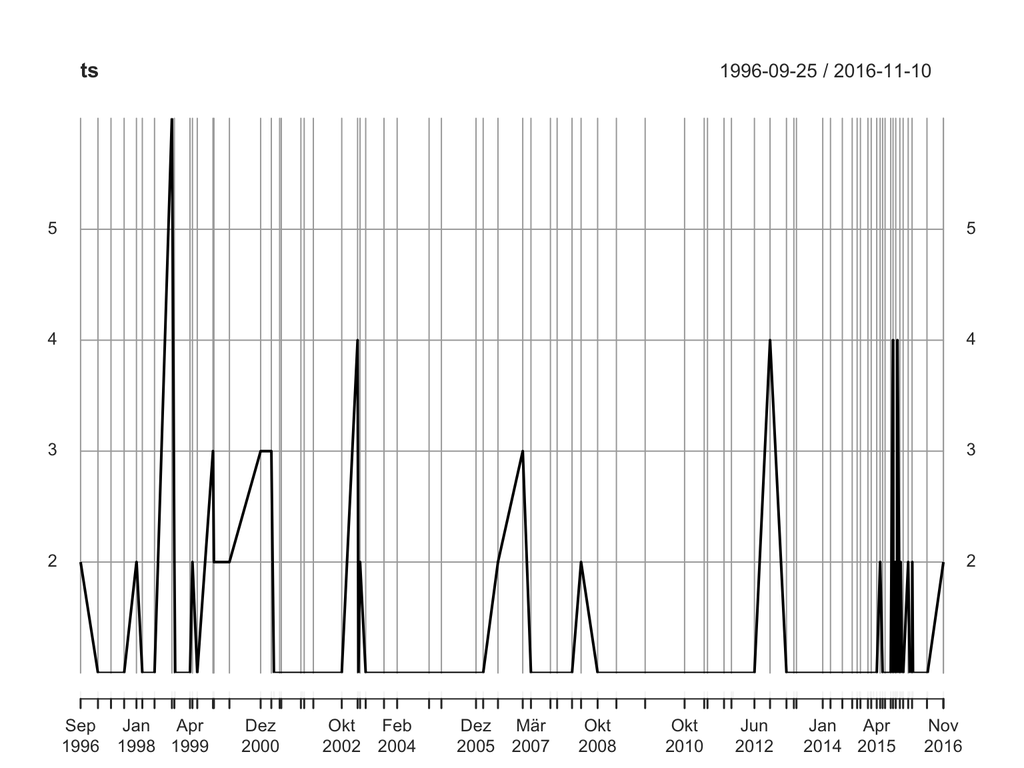

```r
dt <- dispersion("GERMAPARL", query = "Flüchtlings", sAttribute = "date")
ts <- xts(x = dt[["count"]], order.by = as.Date(dt[["date"]]))
plot(ts)
```

Das sieht wenig aussagekräftig aus. Wir sollten daher einen Weg finden, die Zählung auf einen größeren Zeitraum zu aggregieren.

# Woche - Monat - Quartal - Jahr

Als Zeiteinheit für eine Aggregation über den einzelnen Tag hinaus werden wir Woche, Monat, Quartal und Jahr verwenden. Für die Wochen brauchen wir das `lubridate`-Paket.

```r
if (!"lubridate" %in% rownames(installed.packages())) install.packages("lubridate")
library(lubridate)
```

Nun legen wir aggregierte Zeitreihenobjekte an. Der Code hierfür ist bewusst kompakt und vielleicht nicht auf Anhieb verständlich. Im Zweifelsfall … per copy & paste bedienen!

```r
ts_week <- aggregate(ts, {a <- ymd(paste(year(index(ts)), 1, 1, sep = "-")); week(a) <- week(index(ts)); a})
ts_month <- aggregate(ts, as.Date(as.yearmon(index(ts))))
ts_qtr <- aggregate(ts, as.Date(as.yearqtr(index(ts))))
ts_year <- aggregate(ts, as.Date(sprintf("%s-01-01", gsub("^(\\d{4})-.*?$", "\\1", index(ts)))))
```

Welche Aggregation der Zeitreihe erscheint Ihnen am sinnvollsten?

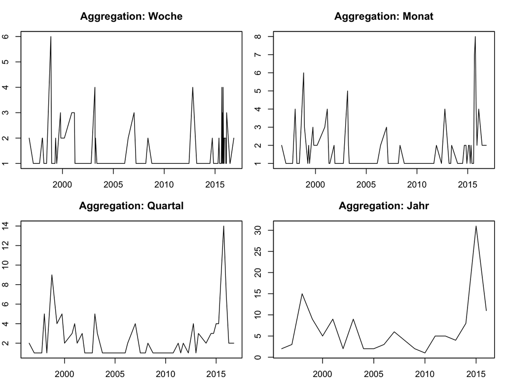

```r
par(mfrow = c(2,2), mar = c(2,2,3,1))
plot(ts_week, main = "Aggregation: Woche"); plot(ts_month, main = "Aggregation: Monat");
plot(ts_qtr, main = "Aggregation: Quartal"); plot(ts_year, main = "Aggregation: Jahr")
```